# 邓泽霖-简历

# 邓泽霖

**AI 工程方向 · 高级前端工程师** · 4 年大厂经验 · 连续 **2 年 A 绩效**

188-4617-4594 · 2597419838@qq.com · [个人主页](https://zachary-lz.vercel.app) · github.com/zachary-lz-glm

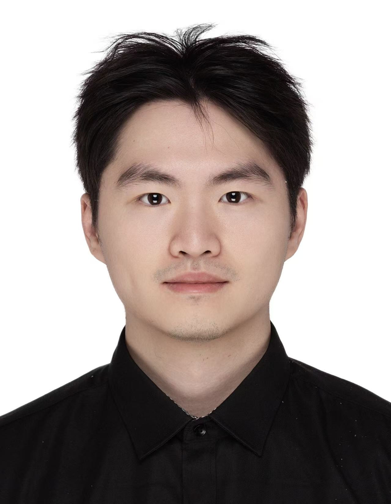

## 个人优势

**AI 工程化方向独立落地者** —— 独立设计并落地 SDD（Spec-Driven Development）体系：6 文件 SSOT 知识库 + 11 步 PRD→Spec 蒸馏工作流 + 8 种证据链 + 三层质量门控，清晰区分 Vibe Coding 与标准化 AI 研发的边界。

- **Agent / Agentic Workflow 工程实践**：独立搭建 Claude Code 双 Skill 工作流，跑通 PRD→Spec→Plan→人工 Review→反馈回流闭环；深度实践 Prompt / Context Engineering、Tool Use、MCP 协议、RAG（BM25 + 语义混合检索 + RRF）。
- **前端架构 + BFF 全栈能力**：主导 Schema 驱动营销中台（BFF 模板引擎 + 前端动态渲染 + 双重求值联动引擎）与 400+ 营销权益组件库，支撑 20+ 种活动类型、8 个业务项目。

## 专业技能

**AI 工程化（差异化优势）**：SDD / Spec-Driven · Claude Code Skill 工作流 · Prompt Engineering · Context Engineering · Harness Engineering · RAG · MCP 协议 · Function Calling · LangGraph · Agent Loop · Claude API

**前端 & 架构**：React + TypeScript · Redux · Node.js Serverless BFF · Lerna + Nx Monorepo · Schema 驱动架构 · Rollup / Webpack · 微前端（qiankun）

**工程效能**：Changesets · zx 自动化 · CI/CD 流水线 · Sentry 监控 · Service Worker 缓存

## 工作经历

**滴滴出行 · 国际化事业部** ｜ 高级前端工程师 ｜ 2022.06 - 至今

主导国际化营销中台前端架构 + AI 工程化体系搭建。独立落地 SDD 全流程（PRD 蒸馏工作流），主导 Schema 驱动架构和 400+ 营销权益组件库。覆盖 10+ 国家、20+ 种活动类型，新活动上线效率提升 70%+。连续 2 年 A 绩效，核心交付质量团队前列。

## 项目经历

### SDD 工作流落地 — PRD 蒸馏到可执行开发计划

*独立设计 + 落地 · Claude Code Skill · MCP 协议 · Prompt / Context Engineering · Harness 约束体系*

**背景**：B 端 PRD 到代码缺少可追溯的中间产物（Spec），导致 AI Coding 产出不可控、需求理解偏差返工频发。基于 Claude Code + MCP 实现 Spec 自动蒸馏，用 Cursor Agent Mode 按 Spec 驱动编码。

**行动**： - **双 Skill 知识底座**：知识库构建 6 模式 + Spec 蒸馏 11 步工作流，反馈回流闭环让 Spec 越用越准。 - **SSOT 规范体系**：6 文件按关注点分离（代码结构 / 编码规则 / 跨层契约 / PRD 路由 / 业务领域 / 实体索引），5 条边界规则避免 AI 编码知识污染。 - **AI Coding 质量管控**：8 种证据类型（含负向搜索 negative_code_search）+ PRD 入口三级门禁，降低返工率。

**结果**：PRD 到开发计划耗时从 **5h/需求 降到 2h/需求**（5 需求对照）；文件级准确率 **80%**；同一 PRD 跑 10 次一致性从 **40% 提升到 85%+**；已在 B 端 **20+ 人团队推广**，后端基于此迭代。

### Schema 驱动营销中台 — BFF 动态生成 + 前端动态渲染

*前端 + BFF 架构设计（与导师 5-5 主导）· React · TypeScript · Node.js Serverless · Lerna + Nx*

**背景**：营销中台覆盖 10+ 国家、20+ 种活动类型，每种活动字段组合与联动规则不同。传统方式每新增一种活动需前后端各写一套，周期长易错（老代码月均 10+ 线上事故）。

**行动**： - **BFF 模板引擎**：模板驱动 Schema 生成，按活动类型分文件管理（25 模板），联动模板复用渲染 handler。 - **双重求值联动引擎（自研 DSL injectDActions）**：一次声明，BFF 端 safeEval 求初始状态（SSR 正确）+ 序列化 d_actions 给前端运行时联动，支持 fetchApi 型与 state 型。 - **前端渲染引擎 + Monorepo 治理**：嵌套路径拍平 + 注册表 35+ 组件动态渲染 + 发布订阅联动；Lerna + Nx 管理 15+ 业务模块。

**结果**：新增活动类型前端 **零代码**，上线周期从 **2 周缩短到 3 天**，累计支撑 **20+ 种活动类型**，联动配置复用率 **80%+**，上线 2 年仅 2-3 起小 bug（老代码月均 10+）。

### 营销权益组件库 — 400+ 权益 React 组件库

*架构设计 + 核心开发（独立完成）· React · TypeScript · Rollup · Changesets*

**背景**：营销平台管理 400+ 种权益（优惠券、折扣、积分、立减等）全生命周期，类型持续增长，原方案每新增一种都需硬编码，维护成本高。

**行动**： - **Register 注册模式**：内置 24 组件 + 运行时注册自定义权益（add / addMultipleCmps），新增权益无需改 SDK。 - **Schema 同构渲染**：组件库与活动表单共享 Schema 渲染架构，两个消费者复用同一套引擎。 - **Rollup 双模打包**（ESM + CJS + 类型声明）+ peerDependencies 隔离 + Changesets 语义化发版；接入支持组件 / 函数调用 / 微前端三形态。

**结果**：覆盖 **8 个业务项目**，累计接入 **400+ 种权益 SKU**（底层组件 30-40 个），新权益接入从 **2 天缩短到 2 小时**，零 breaking change 运行 **18 个月+**。

## 加分项

- **AI Native App 0-1 落地**：prd-tools 从底层设计 AI 优先工作流范式（非给已有产品加 AI），完整闭环：知识库 → PRD 蒸馏 → Spec/Plan → 人工 Review → 反馈回流。
- **Claude Code 插件开发**：独立开发 2 个 Skill 插件（build-reference + prd-distill），零依赖设计（不依赖 Node / LLM Key），团队拿到即用。
- **团队技术影响力**：主导《中台开发规范》《BFF 接口规范》《CI/CD 流水线规范》落地及多场业务技术分享；B 端 20+ 人团队 AI 工作流推广者。

## 教育背景

**黑龙江大学** ｜ 计算机科学与技术 ｜ 本科 ｜ 2018.09 - 2022.06